# Teoria

GIACOMO SACCAGGI

## Teoria degli alberi di regressione e classificazione

### Generalità

- Con il termine albero si indica un tipo di rappresentazione che indica una suddivisione dello spazio delle variabili esplicative $X$
- Le componenti di un albero
  - La radice (*root*): dove avviene la prima divisione

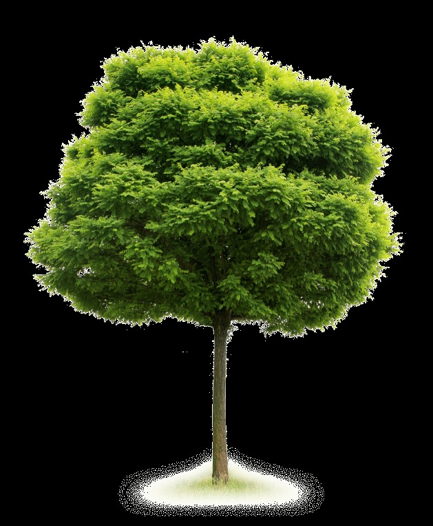

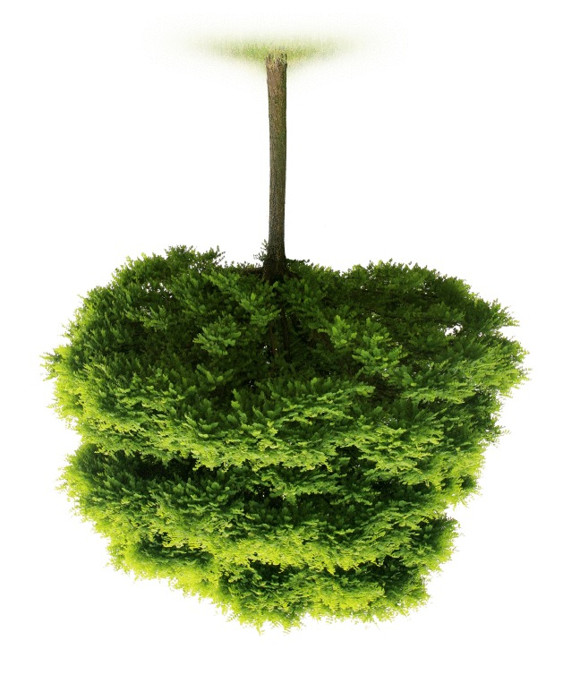

  - Nodi (*internal nodes*): diramazioni
  - Rami (*branches*): congiungono i nodi
  - Nodi terminali/foglie (*terminal nodes*/*leaves*): foglie, ovvero nodi che non danno luogo ad ulteriori diramazioni

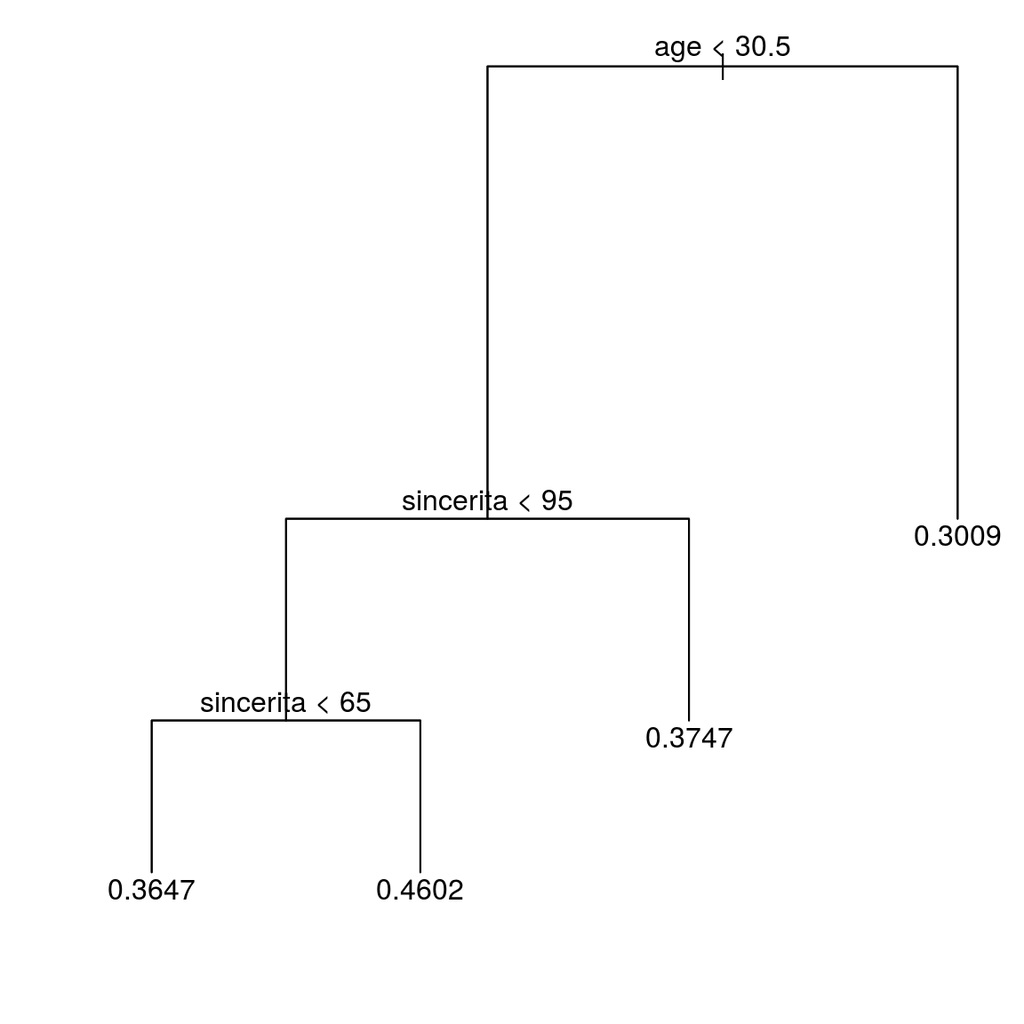

- I nodi possono essere di due tipi
  - Genitore
  - Figlio
- Ogni nodo può essere sia genitore che figlio tranne
  - La radice che è necessariamente genitore
  - I nodi terminali che sono necessariamente figli
- Quando si parla di dimensione dell’albero si fa riferimento al numero di nodi terminali/foglie
- Gli alberi di regressione e classificazione si basano sulle seguenti fasi
  1. Crescita
  2. Potatura

### Alberi di regressione

#### Crescita

- L’albero partiziona lo spazio delle variabili in regioni $R_1,\ldots, R_K$ secondo una sequenza logica che coinvolge le singole variabili esplicative
  - Al generico nodo si ha una condizione del tipo $X_j \lt c$
  - In linea di principio, si possono considerare condizioni più complesse e che coinvolgono più variabili
    - Per esempio $X_1+X_2^2 \lt 0$
- Nel seguito si considereranno condizioni binarie semplici che coinvolgono una sola variabile esplicativa alla volta
  - Variabile continua: condizioni del tipo $X_j \lt c$
  - Variabile categoriale: condizioni del tipo $X_j=c$ oppure $X_j\in \mathcal I$, $\mathcal I=\{c,d\}$
- Date $n$ osservazioni, la costruzione dell’albero di regressione si basa sulla seguente regola
  - Trovare una partizione dello spazio della variabili in modo tale da minimizzare la seguente quantità (somma dei quadrati dei residui)
    $$\sum_{i=1}^n (y_i-\hat y_i)^2$$
  - $\hat y_i$ valore previsto per $y_i$
  - Come si è visto, il valore stimato dall’albero è costante all’interno di una regione, perciò
    $$\sum_{i=1}^n (y_i-\hat y_i)^2=\sum_{k=1}^K\sum_{i: x_i\in R_k}(y_i-\hat y_{R_k})^2$$
  - In particolare, per un’albero di regressione, $\hat y_{R_k}$ è la media delle osservazioni nella regione $R_k$
    $$\hat y_{R_k}=\frac{1}{\mbox{card}(R_k)}\sum_{i: x_i\in R_k} y_i$$
    - $\mbox{card}(R_k)$ è la cardinalità della regione $R_k$, definita come numero di osservazioni che si trovano al suo interno
- Stabilita la funzione di perdita non resta che iniziare a partizionare lo spazio delle variabili in $K$ regioni
- Sorgono alcune domande/problemi
  1. Forma delle regioni: in linea di principio le regioni possono avere qualsiasi forma
     - Il tipo di condizioni binarie imposte fa sì che le regioni siano dei rettangoli/iperrettangoli
  2. Modo di procedere: considerare tutte le possibili partizioni dello spazio delle variabili in $K$ regioni, anche se di forma prestabilita, è computazionalmente proibitivo
- Per ovviare alla problematica 2, la strategia utilizzata è chiamata divisione ricorsiva binaria (*recursive binary splitting*)
  - È un approccio
    - *Top-down*: si parte dalla radice dell’albero, in cui c’è un unica regione, si fa una prima divisione e si procede dividendo ulteriormente le regioni ottenute ad ogni passo
    - *Greedy* (avido): ad ogni passo viene fatta la miglior divisione in quel preciso passo senza verificare se la divisione corrente può essere cambiata in favore di un’altra che, ad uno step successivo, porterebbe a risultati migliori
- Per mettere in atto la divisione ricorsiva binaria bisogna scegliere la variabile esplicativa e il punto in cui effettuare la divisione
- Senza perdita di generalità, consideriamo di essere al primo step, cioè alla radice dell’albero
  - Per decidere quale variabile usare alla prima divisione bisogna trovare quella variabile $X_j$ (una tra le $p$ a disposizione) e il punto in cui effettuare la divisione, chiamiamolo $c$, tale per cui le regioni
    $$R_{1}=\{X|X_j \lt c \}\quad\mbox{e}\quad R_{2}=\{X|X_j\geq c\}$$
    rendono minima la quantità
    $$\sum_{k=1}^2\sum_{i: x_i\in R_k}(y_i-\hat y_{R_k})^2$$
- In generale, il problema di cui sopra può essere formalizzato nel seguente modo
  - Per ogni $j=1,\ldots,p$ e $c$, trovare le due regioni
    $$R_{1}(j,c)=\{X|X_j \lt c \}\quad\mbox{e}\quad R_{2}(j,c)=\{X|X_j\geq c\}$$
    che rendono minima la funzione
    $$\sum_{i: x_i\in R_1(j,c)}(y_i-\hat y_{R_1(j,c)})^2+\sum_{i: x_i\in R_2(j,c)}(y_i-\hat y_{R_2(j,c)})^2$$
- Una volta determinata la prima divisione, come si procede?
  - Assumiamo che la divisione sia avvenuta considerando la variabile 3, cioè $X_3$, e il punto di divisione $c$
  - Per ogni $j=1,\ldots,p$ e $d$, scegliere una delle seguenti coppie di regioni
    $$\bar R_{1}(j,d)=\{R_{1}(3,c)|X_j \lt d \}\quad\mbox{e}\quad \bar R_{2}(j,d)=\{R_{1}(3,c)|X_j\geq d\}$$
    $$\tilde R_{1}(j,d)=\{R_{2}(3,c)|X_j \lt d \}\quad\mbox{e}\quad \tilde R_{2}(j,d)=\{R_{2}(3,c)|X_j\geq d\}$$
    vedendo quale funzione assume il valore più piccolo
    $$\sum_{i: x_i\in \bar R_1(j,d)}(y_i-\hat y_{R_1(3,c)})^2+\sum_{i: x_i\in \bar R_2(j,d)}(y_i-\hat y_{R_1(3,c)})^2$$
    $$\sum_{i: x_i\in \tilde R_1(j,d)}(y_i-\hat y_{R_2(3,c)})^2+\sum_{i: x_i\in \tilde R_2(j,d)}(y_i-\hat y_{R_2(3,c)})^2$$
- In generale, divisioni successive dividono le regioni individuate in uno dei passi precedenti
  - Analogamente a quanto visto sopra, si cercano le due regioni che minimizzano la somma dei quadrati dei residui (nelle nuove regioni)
- Una variabile utilizzata in una divisione ad un passo precedente può essere usata in una divisione ad un passo successivo?
- Secondo i criteri elencati finora, ci sono partizioni ammissibili e inammissibili

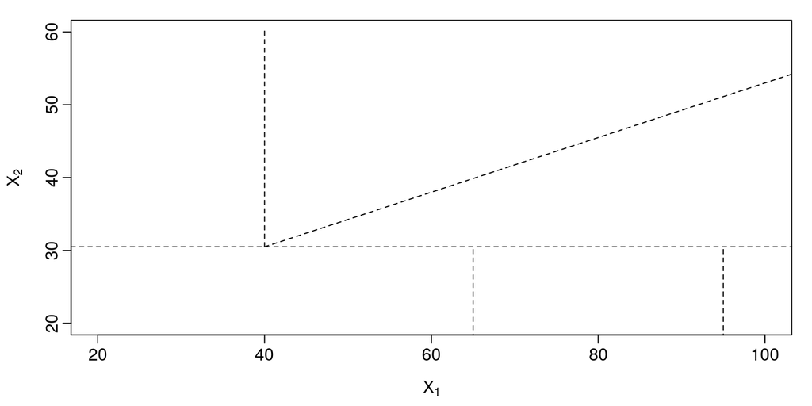

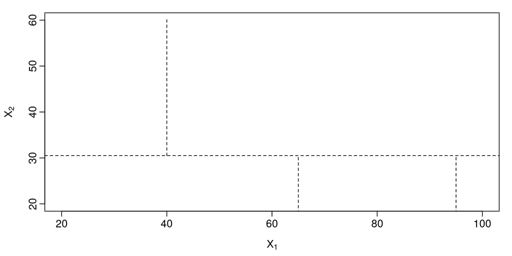

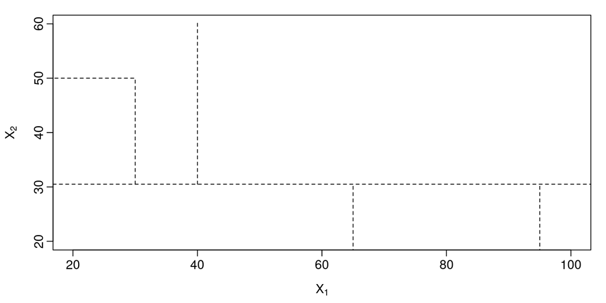

- Una volta ultimata la crescita dell’albero resta solo da fare la previsione nel test set
  - La previsione è data dal valore medio delle osservazioni che sono nella regione a cui l’osservazione del test set appartiene
  - Se l’osservazione del test set $x_o$ soddisfa $x_o\in R_k$ allora la previsione sarà
    $$\hat y_{R_k}=\frac{1}{\mbox{card}(R_k)}\sum_{i: x_i\in R_k} y_i$$
    - $y_i$ sono le risposte nel training set
- Una osservazione sui possibili punti di divisione
  - Se la variabile è continua, le condizioni saranno del tipo $X_j \lt c$
    - La pratica dice di scegliere $c$ come il valore medio tra due valori consecutivi piuttosto che scegliere uno dei valori osservati (meno errori nel test set)
  - Se la variable è categoriale le condizioni sono del tipo $X_j\in \mathcal I$, dove $\mathcal I$ è un opportuno insieme
    - Supponendo che $X_j$ abbia categorie $\{a,b,c,d\}$, si avranno i possibili punti di divisione
      - $\mathcal I=\{a\}$, $\bar{\mathcal I}=\{b,c,d\}$
      - $\mathcal I=\{b\}$, $\bar{\mathcal I}=\{a,c,d\}$
      - $\mathcal I=\{c\}$, $\bar{\mathcal I}=\{a,b,d\}$
      - $\mathcal I=\{d\}$, $\bar{\mathcal I}=\{a,b,c\}$
      - $\mathcal I=\{a,b\}$, $\bar{\mathcal I}=\{c,d\}$
      - $\mathcal I=\{a,c\}$, $\bar{\mathcal I}=\{b,d\}$
      - $\mathcal I=\{a,d\}$, $\bar{\mathcal I}=\{b,c\}$

#### Potatura

- La potatura è necessaria perché la somma dei quadrati dei residui è minimizzata con un albero di dimensione elevata e quindi complesso
  - Questo comporterebbe un adattamento eccessivo ai dati
  - Implica scarsa capacità di generalizzazione
    - Scarso potere previsivo nel test set
- Invece di ricorrere alla potatura, potremmo pensare di limitare la crescita dell’albero
- La divisione ricorsiva binaria potrebbe essere modificata in questo modo
  - Si effettua una suddivisione solo se la diminuzione della somma dei quadrati dei residui supera una soglia abbastanza elevata
  - Il ragionamento può essere applicato già alla radice dell’albero, ma sarebbe più sensato in passi successivi
    - Nel caso venisse applicato in passi successivi, si potrebbe guardare alla diminuzione della somma dei quadrati dei residui in termini comparativi con il passo precedente
- La strategia descritta sopra è sensata e ragionevole, ma nella pratica si preferisce agire diversamente
  - Limitare la crescita dell’albero è una strategia miope
    - Data la natura della divisione ricorsiva binaria, non possiamo sapere in anticipo cosa succederà in passi successivi
    - Potremo perdere delle “buone” divisioni solo perché la divisione corrente non è abbastanza “buona”
- La strategia correntemente usata consiste nel far crescere molto l’albero e poi potarlo
  - In questo modo si ottiene un *sotto albero* $T$
  - Per costruzione la dimensione di $T$ è minore, o al più uguale, a quella dell’albero di partenza $T^0$

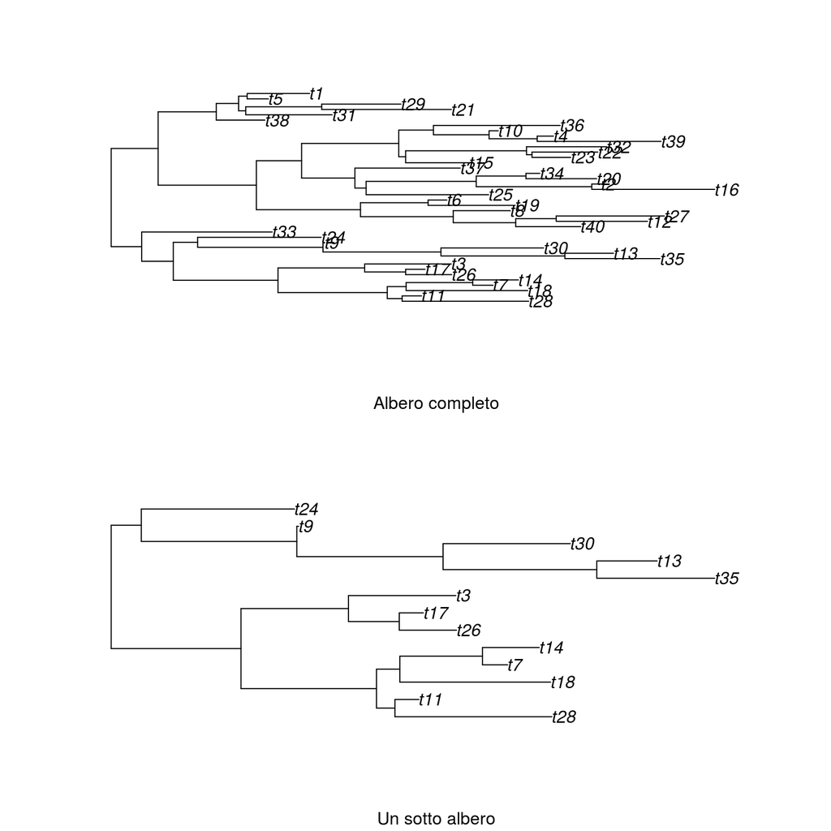

- Che dimensione deve avere l’albero di partenza?
  - Si fa crescere l’albero in modo tale che ogni foglia contenga non più di un numero prefissato di osservazioni
- In generale, il numero di sotto alberi può essere molto elevato
  - Computazionalmente proibitivo
    - Sia che si abbiano molte variabili esplicative, sia quando il loro numero è modesto
      - La strategia è far crescere “molto” l’albero
- Albero completo con 40 foglie e alcuni sotto alberi

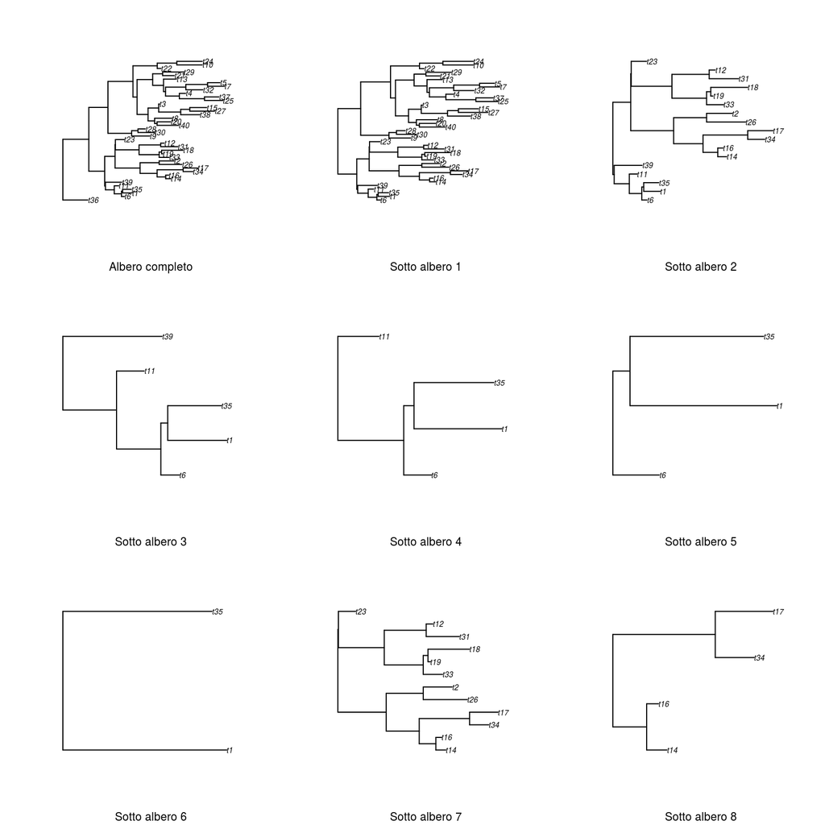

- La strategia utilizzata permette di individuare un numero ragionevole di sotto alberi da prendere in considerazione
  - Viene chiamata *cost complexity pruning* (“potatura che considera la complessità (dell’albero)”)
- Il fulcro della strategia è la seguente somma dei quadrati dei residui modificata
  $$\sum_{k=1}^K\sum_{i:x_i\in R_k}(y_i-\hat y_{R_k})^2 + \alpha |T^\alpha|= \sum_{k=1}^{|T^\alpha|}\sum_{i: x_i\in R_k}(y_i-\hat y_{R_k})^2 + \alpha |T^\alpha|$$
  - $|T^\alpha|$ è la dimensione dell’albero
  - Il parametro $\alpha$ è reale e controlla l’adattamento dell’albero ai dati e la dimensione dell’albero
  - Al variare di $\alpha$, otteniamo una sequenza di sotto alberi $T^{\alpha}$
    - Quando $\alpha=0$ otteniamo l’albero iniziale $T^0$
    - Man mano che $\alpha$ cresce si penalizzano sempre di più alberi di dimensioni elevate
      - Si ottengono quindi alberi progressivamente più piccoli
  - Se $\alpha_1 \lt \alpha_2$ allora si ha che la dimensione di $T^{\alpha_1}$ sarà maggiore o uguale a quella di $T^{\alpha_2}$

#### Miglior sotto albero

- Per scegliere il miglior sotto albero si procede con la $K$-fold cross validation
- I passi da seguire sono i seguenti
  1. Si fa crescere l’albero, $T^0$, usando la divisione ricorsiva binaria
     - La crescita si ferma quando tutte le foglie hanno non più di un certo numero di osservazioni
       - Solitamente si sceglie 5
  2. Potare $T^0$ secondo il cost complexity pruning in funzione del parametro $\alpha$
     - Si ottiene quindi una sequenza di $m$ alberi in funzione di ogni valore del vettore $\alpha=(\alpha_1,\ldots,\alpha_m)$
  3. Ricorrere alla $K$-fold cross validation per scegliere il valore ottimo di $\alpha$
     - Per ogni $k=1,\ldots,K$
       1. Ripetere i passi 1 e 2 sul training set corrente (composto dall’unione di $K-1$ insiemi)
       2. Fare la previsione sul test set e calcolare la somma dei quarati dei residui modificata
          - Si ricorda che i passi a e b vanno fatti per ogni valore di $\alpha$ (quindi per ognuno degli $m$ alberi presi in considerazione)
  4. Per ogni $\alpha$ (quindi per ogni albero), fare la media dei valori delle somme dei quadrati dei residui (modificata) in tutti i passaggi della cross validation
  5. Scegliere l’elemento di $\alpha$, diciamo $\alpha^*$, che corrisponde al valore medio minimo delle somme dei quadrati dei residui (modificata)
  6. Il sotto albero cercato è $T^{*}=T^{\alpha^*}$

### Alberi di classificazione

#### Crescita e potatura

- Il modo in cui si cresce e si pota un albero di classificazione è analogo a quanto visto per gli alberi di regressione
- La differenza risiede nel tipo di funzione di perdita utilizzata
  - La somma dei quadrati dei residui non ha alcun senso quando la variabile risposta è categoriale
- La crescita e la potatura si basano su specifiche funzioni di perdita
  - Funzioni di impurità del nodo
    - Sono delle funzioni che controllano se la divisione crea regioni omogenee secondo le categorie della variabile risposta
- L’impurità è sensata e coerente con il modo in cui viene prevista la classe delle osservazioni
  - La classe prevista per un’unità è la classe prevalente nella regione
  - Assumendo che la variabile risposta abbia due livelli, per esempio $\mathcal Y=\{a,b\}$, un’osservazione $y_i$ le cui esplicative appartengono alla regione $R_k$ avrà previsione $\hat y_i=a$ se
    $$\arg\max_{l\in\mathcal Y}\hat p_{kl}=a$$
    $$\hat p_{kl}=\frac{1}{\mbox{card}(R_k)}\sum_{t:x_t\in R_k} I(y_t=l)$$
- Il caso di una suddivisione quando la variabile risposta ha due categorie

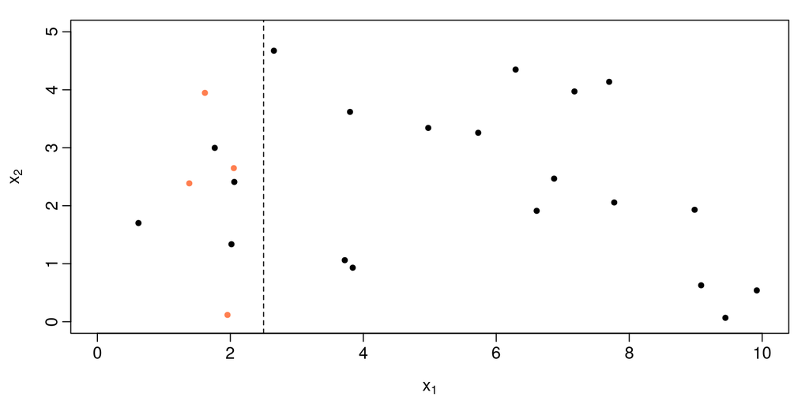

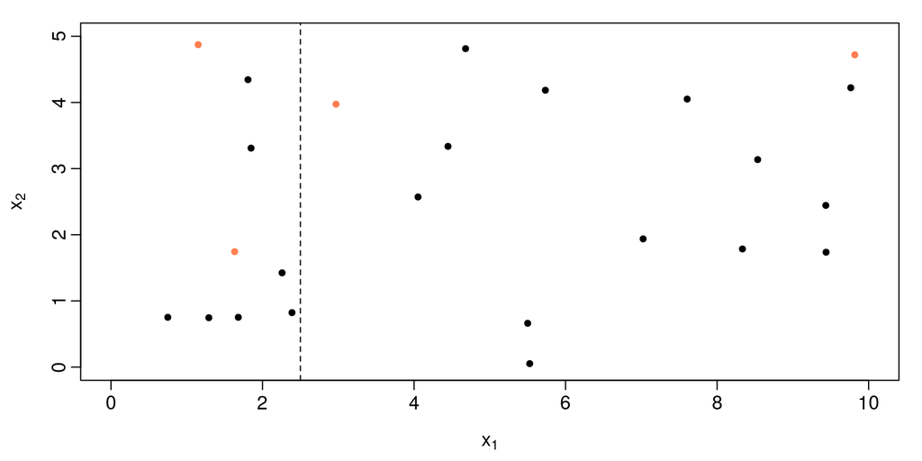

- In letteratura, le funzioni di impurità comunemente usate per individuare la purezza della regione $R_k$ (e quindi del nodo corrispondente) sono
  1. Errore di scorretta classificazione
     $$1-\max_{l\in\mathcal Y} \hat p_{kl}$$
  2. Indice di Gini
     $$\sum_{l \neq l'} \hat p_{kl}\hat p_{kl'}=\sum_{l\in\mathcal Y} \hat p_{kl}(1-\hat p_{kl})$$
  3. Entropia
     $$-\sum_{l\in\mathcal Y} \hat p_{kl}\log\hat p_{kl}$$
     - $\mathcal Y$ è l’insieme delle categorie della variabile risposta
- Il criterio usato per valutare la bontà della divisione di un’arbitraria regione $R$ in due nuove regioni $R_1$ ed $R_2$ rispetto alla variabile $X_j$, e al punto di divisione $c$, si basa sulla massimizzazione della quantità
  $$i(R) - p_1 i(R_1(j,c)) - p_2 i(R_2(j,c))$$
  che viene chiamata guadagno di informazione
  - $i(R)$ è l’impurità della regione $R$, calcolata a partire da una delle misure elencate sopra
  - $i(R_1(j,c))$ è l’impurità della regione $R_1(j,c)$, calcolata a partire da una delle misure elencate sopra
  - $i(R_2(j,c))$ è l’impurità della regione $R_2(j,c)$, calcolata a partire da una delle misure elencate sopra
  - $p_1$ e $p_2$ sono le proporzioni di osservazioni che andranno a formare, rispettivamente, le regioni $R_1(j,c)$ e $R_2(j,c)$
- Per quanto riguarda la crescita dell’albero si tende a non utilizzare l’errore di scorretta classificazione in quanto è poco informativo circa la purezza del nodo
- Quanto visto sopra riguarda la crescita dell’albero
  - Occupiamoci della potatura
- La potatura viene condotta come nel caso degli alberi di regressione
  - La funzione che è alla base della strategia
    $$\sum_{k=1}^{|T^\alpha|}\sum_{i: x_i\in R_k}(y_k-\hat y_{R_k})^2 + \alpha |T^\alpha|$$
    va sostituita con
    $$\sum_{k=1}^{|T^\alpha|}(1-\max_{l\in\mathcal Y} \hat p_{kl})p_k + \alpha |T^\alpha|$$
  - $1-\max_{l\in\mathcal Y} \hat p_{kl}$ è l’errore di scorretta classificazione nella regione $k$
  - $p_k$ è la proporzione di osservazioni che appartengono alla regione $K$
- Come nel caso della regressione, la funzione di cui sopra va minimizzata

# Ensamble learning

- I metodi di Ensemble sono tecniche che creano più modelli e poi li combinano per produrre risultati migliori
- I modelli che vengono usati e combinati in questa tecnica sono chiamati **base learners** o **weak learners**
- Ensemble learning è molto utilizzato perchè riesce a creare modelli con una capacità predittiva molto accurata sfruttando attraverso il bootstrap per combinare i weak learners
- I metodi di Ensemble aumentano i **tempi computazionali** e riducono l’ **Interpretabilità**
- Ad esempio, gli alberi di classificazione e regressione sono semplici e utili per l’interpretazione. Tuttavia, in genere non sono competitivi con altri approcci in termini di accuratezza delle previsioni
- Nella **random forest** vengono creati più alberi che vengono poi combinati per produrre una singola previsione. La combinazione di un gran numero di alberi può spesso comportare notevoli miglioramenti nella precisione della previsione, a spese di una perdita di interpretazione

# Instabilità degli alberi

- Lo svantaggio principale degli alberi è che sono piuttosto instabili (alta varianza)
- In altre parole, una piccola modifica nei dati si traduce spesso in un albero completamente diverso
- Uno dei motivi principali di questa instabilità è che se una divisione cambia, cambiano anche tutte le suddivisioni sottostanti, propagando così la variabilità
- Quindi è necessario controllare la varianza o **stabilizzare** le previsioni fatte dagli alberi
- In tal modo, possiamo migliorare notevolmente la precisione della previsione, ma soffriamo in termini di interpretabilità.

# Il boostrap

- Il **bootstrap** è un utile strumento di ricampionamento in statistica
- Un esempio di bootstrap di dimensioni $n$ per il training set è
  $$(\tilde{x}_1, \tilde{y}_1), (\tilde{x}_2, \tilde{y}_2), \ldots, (\tilde{x}_n, \tilde{y}_n)$$
  dove ogni $(\tilde{x}_i, \tilde{y}_i)$ sono estratti casualmente (da una Uniforme) da
  $$(x_1, y_1), (x_2, y_2), \ldots, (x_n, x_n)$$
  con **reinserimento**
- Non tutti i punti del training set sono rappresentati in un campione bootstrap e alcuni possono comparire più di una volta. La probabilità che un’osservazione non sia tracciata in un’estrazione è $1 - \frac{1}{n}$
- Per $n$ grandi, la probabilità che un’osservazione non venga tracciata in nessuna delle estrazioni $n$ è
  $$\lim_{n\rightarrow \infty} \left(1- \frac{1}{n}\right)^n = \frac{1}{e} \approx 0.368$$
- Possiamo aspettarci che $\approx 1/3$ delle $n$ osservazioni originali siano **out-of-bag** (OOB)

Il bootstrap implica la selezione casuale di sottoinsiemi di osservazioni dal dataset originario. Per ogni campione bootstrap, le unità non selezionate possono essere utilizzate come unità test. In media, ogni albero si avvale di circa 2/3 delle osservazioni; in questo modo abbiamo circa 1/3 delle osservazioni per fare cross-validazione

# Random Forest

Una foresta casuale (in inglese: random forest) è un classificatore d’insieme che è composto da molti alberi di decisione e dà in uscita la classe che corrisponde all’uscita delle classi degli alberi presi individualmente. L’algoritmo per indurre a una foresta casuale fu sviluppato da Leo Breiman e Adele Cutler. Il nome viene dalle foreste di decisione casuali che furono proposte per primo da Tin Kam Ho dei Bell Labs nel 1995.

La risposta di ciascun albero dipende da una serie di valori predittivi scelti in modo indipendente (con sostituzione) e con la stessa distribuzione per tutti gli alberi nella foresta, che è un sottoinsieme dei valori predittivi del set di dati originale. La dimensione ottimale del sottoinsieme di variabili predittive è data da $\log_2( M + 1)$, dove $M$ è il numero di input.

**Perchè usare solo $M$ predittori?**

Supponiamo di avere un predittore molto importante e altri predittori non così importanti Nella collezione di alberi bagged, tutti, o la maggior parte, utilizzeranno il predittore più importante come primo split! Tutti gli alberi ottenuti con il bagging tenderanno ad essere simili. Da cui tutte le $B$ previsioni saranno altamente correlate con conseguente bassa riduzione della variabilità del modello. Le foreste casuali, utilizzando, ad ogni passo, un sottoinsieme casuale di predittori, produrranno alberi diversi fra loro e quindi “de-correlati”. Questo dovrebbe portare ad una maggiore riduzione della varianza del modello.

Per **problemi di classificazione** (Dropout<-ad es. {$SI/NO$}), dato un insieme di alberi semplici e un insieme di variabili predittive casuali, il metodo Random Forest definisce una funzione di margine che misura la misura in cui il numero medio di voti per la classe corretta supera il voto medio per qualsiasi altra classe presente nella variabile dipendente. Questa misura ci fornisce non solo un modo conveniente per fare previsioni, ma anche un modo per associare una misura di fiducia a tali previsioni.  
Per **problemi di regressione** (giorni di guarigione<- ad es. {$1,2,3,...$}), le foreste casuali sono formate da alberi semplici in crescita, ognuno in grado di produrre un valore di risposta numerica. Anche qui, il set di predittori viene selezionato casualmente dalla stessa distribuzione e per tutti gli alberi. Dato quanto sopra, l’errore quadratico medio per una foresta casuale è dato da:

$$mean \space error = (observed - tree \space response)^2$$
Le previsioni della Random Forest sono considerate la media delle previsioni degli alberi:

$$Random \space Forest \space Prediction = \frac{1}{K} \sum_{k=1}^K{tree \space response \space_k}$$
Dove l’indice $k$ identifica gli alberi creati.
In genere, le foreste casuali possono incorporare in modo flessibile i dati mancanti nelle variabili predittive. Quando vengono rilevati dati mancanti per una particolare osservazione (caso) durante la creazione del modello, la previsione fatta per quel caso si basa sull’ultimo nodo (non terminale) precedente nel rispettivo albero. Quindi, ad esempio, se in un determinato punto della sequenza degli alberi viene selezionata una variabile predittore nel nodo radice (o altro nodo non terminale) per il quale alcuni casi non hanno dati validi, la previsione per tali casi è semplicemente basata su la media complessiva nel nodo radice (o altro nodo non terminale). Pertanto, non è necessario eliminare i casi dall’analisi se non sono disponibili dati per alcuni predittori, né è necessario calcolare statistiche suddivise surrogate.

# Misure di importanza delle singole variabili

La Random Forest in genere migliora la precisione nelle previsioni ma aumenta anche la difficoltà di interpretazione del modello.

Se abbiamo centinaia di alberi, è difficile capire quali siano le variabili più importanti ed il loro contributo

Possiamo ancora ottenere una panoramica generale dell’importanza di ogni predittore usando dei grafici e delle misure di influenza relativa.

Come si fa a decidere quali variabili sono più utili nel predire la risposta?

Le misure di influenza relativa danno un punteggio per ogni variabile. Tipicamente rappresentato graficamente

Per gli **alberi di regressione** questi punteggi rappresentano la diminuzione dello MSE (o RSS) quando si effettua uno split sull’albero su una particolare variabile

Per **alberi di classificazione** i punteggi rappresentano la diminuzione dell’indice Gini (o altro)

Un numero vicino a zero indica che la variabile non è importante e che può essere eliminata. Viceversa, maggiore il punteggio tanto maggiore l’influenza della variabile.